# Fitting the ST model for the LUR

Sheena Martenies

3/19/2020

### Description:

After meeting with Josh Keller (Statistics, CSU), we decided to try to implement the modeling framework used by the MESA Air team (Keller et al., 2015). This was implemented using the SpatioTemporal package in R.

The original paper used PLS to select the spatial covariates. That will be the eventual approach for this analysis, but for now, I’m going to use the covariates selected by the LASSO model (see 16a_LUR_BC_average.R)

Update 03.18.20: I was receiving an error when trying to use the estimate.STmodel() function from the SpatioTemporal package. I emailed Josh Keller for advice, and he responded with some suggestions. I’ve pasted his email response at the end of this script for safe keeping

Basically, I’m going to start with the following:

- Simple model (i.e., only one time trend)
- iid covariance structure

### Step 1. Data formatting

Josh Keller made key revisions to the estimate.STmodel() function. Loading his version here and examining the objects from the `SpatioTemporal` package

```r
source(here::here("Code", "functions_model.R"))

data(mesa.data.raw, package="SpatioTemporal")

names(mesa.data.raw)
```

```
## [1] "X"             "obs"           "lax.conc.1500"
```

```r
head(mesa.data.raw$X) # Spatial covariates
```

```
##         ID         x        y     long     lat type log10.m.to.a1
## 1 60370002 -10861.67 3793.589 -117.923 34.1365  AQS      2.861509
## 2 60370016 -10854.95 3794.456 -117.850 34.1443  AQS      3.461672
## 3 60370030 -10888.66 3782.332 -118.216 34.0352  AQS      2.561133
## 4 60370031 -10891.42 3754.649 -118.246 33.7861  AQS      3.111413
## 5 60370113 -10910.76 3784.099 -118.456 34.0511  AQS      2.762193
## 6 60371002 -10897.96 3797.979 -118.317 34.1760  AQS      2.760931
##   log10.m.to.a2 log10.m.to.a3 log10.m.to.road km.to.coast
## 1      4.100755      2.494956        2.494956   15.000000
## 2      3.801059      2.471498        2.471498   15.000000
## 3      3.695772      1.830197        1.830197   15.000000
## 4      2.737527      2.451927        2.451927    1.023311
## 5      3.687412      2.382281        2.382281    6.011075
## 6      4.035977      1.808260        1.808260   15.000000
##   s2000.pop.div.10000
## 1            1.733283
## 2            1.645386
## 3            6.192630
## 4            2.088930
## 5            7.143731
## 6            4.766780
```

```r
class(mesa.data.raw$X)
```

```
## [1] "data.frame"
```

```r
head(mesa.data.raw$obs) # Observations at each sampling site (wide: time vs. location)
```

```
##            60370002 60370016 60370030 60370031 60370113 60371002 60371103
## 1999-01-13 4.577684 4.131632       NA       NA 4.727882 5.352608 5.281452
## 1999-01-27 3.889091 3.543566       NA       NA 4.139332 4.876832 4.846044
## 1999-02-10 4.013020 3.632424       NA       NA 4.054051 4.717611 4.665429
## 1999-02-24 4.080691 3.842586       NA       NA 4.392799 4.877139 4.830275
## 1999-03-10 3.728085 3.396944       NA       NA 3.960577 4.252480 4.163820
## 1999-03-24 3.751913 3.626161       NA       NA 3.958741 4.180627 4.240120
##            60371201 60371301 60371601 60371602 60371701 60372005 60374002
## 1999-01-13 4.984585 5.463134 5.316398       NA 5.081886 4.900640 4.995868
## 1999-01-27 4.100073 5.213077 5.010987       NA 4.674858 4.381561 4.785056
## 1999-02-10 4.056365 5.037477 4.770632       NA 4.715861 4.247208 4.493267
## 1999-02-24 4.382803 5.127157 4.960104       NA 4.905827 4.450186 4.440054
## 1999-03-10 3.808937 4.656825 4.205851       NA 4.403685 3.792204 4.035339
## 1999-03-24 3.794791 4.583794 4.383694       NA 4.472207 3.836844 3.995005
##            60375001 60375005 60590001 60590007 60591003 60595001 L001 L002
## 1999-01-13 5.165070       NA 4.847385       NA 4.603461 4.834629   NA   NA
## 1999-01-27 4.784252       NA 4.517424       NA 4.414679 4.576023   NA   NA
## 1999-02-10 4.685089       NA 4.217816       NA 4.104592 4.337169   NA   NA
## 1999-02-24 4.676942       NA 4.565771       NA 4.288501 4.573462   NA   NA
## 1999-03-10 4.030772       NA 3.816688       NA 3.374445 3.936019   NA   NA
## 1999-03-24 4.200838       NA 3.795629       NA 3.412111 3.914319   NA   NA
##            LC001 LC002 LC003
## 1999-01-13    NA    NA    NA
## 1999-01-27    NA    NA    NA
## 1999-02-10    NA    NA    NA
## 1999-02-24    NA    NA    NA
## 1999-03-10    NA    NA    NA
## 1999-03-24    NA    NA    NA
```

```r
class(mesa.data.raw$obs)
```

```
## [1] "matrix"
```

```r
head(mesa.data.raw$lax.conc.1500) # ST covariates-- in this case, the CALINE output
```

```
##            60370002 60370016 60370030 60370031 60370113 60371002 60371103
## 1999-01-13   2.3188        0   8.0641   0.1467   2.9894   1.7453   3.0796
## 1999-01-27   1.8371        0   7.3568   0.2397   4.7381   2.7741   4.0758
## 1999-02-10   1.4886        0   6.3673   0.2463   4.3922   2.6177   3.6573
## 1999-02-24   2.5868        0   7.1783   0.1140   3.3456   1.9160   2.7983
## 1999-03-10   1.8996        0   6.3159   0.1537   3.8495   2.2434   3.2737
## 1999-03-24   2.0162        0   6.3277   0.1906   3.2170   1.8760   2.8313
##            60371201 60371301 60371601 60371602 60371701 60372005 60374002
## 1999-01-13        0   4.3355   3.6514   1.6551   0.6840        0   8.3220
## 1999-01-27        0   3.5998   5.8899   2.4706   0.9682        0   6.5495
## 1999-02-10        0   2.8850   4.9941   2.0764   1.1398        0   5.1438
## 1999-02-24        0   4.0051   4.3535   1.9590   0.2790        0   7.5118
## 1999-03-10        0   3.4102   4.4792   1.9948   0.5782        0   6.3891
## 1999-03-24        0   3.1945   4.5385   1.8718   0.8634        0   5.5717
##            60375001 60375005 60590001 60590007 60591003 60595001   L001
## 1999-01-13   9.1542   0.0290   8.0984   2.8260        0   0.2097 3.0659
## 1999-01-27  14.9277   0.0434   6.1531   4.3818        0   0.2061 3.9648
## 1999-02-10  13.3726   0.0550   4.9165   4.4104        0   0.1500 3.5801
## 1999-02-24  10.1036   0.0285   6.9086   3.0511        0   0.2107 2.7203
## 1999-03-10  10.9733   0.0394   6.1697   3.5513        0   0.1748 3.1925
## 1999-03-24  11.5783   0.0334   5.3485   3.0596        0   0.2003 2.7244
##               L002  LC001 LC002   LC003
## 1999-01-13 16.1820 1.4743     0 12.4700
## 1999-01-27 19.0448 2.2429     0 21.7796
## 1999-02-10 15.4424 2.3170     0 22.2238
## 1999-02-24 21.4637 1.6237     0 13.3942
## 1999-03-10 18.1867 1.8615     0 15.8166
## 1999-03-24 16.9203 1.6814     0 18.0503
```

```r
class(mesa.data.raw$lax.conc.1500) # Separate matrices for each predictor
```

```
## [1] "matrix"
```

Get my data to match the Mesa data set. When I ran this the first time, Site 61 looked much different from the others, so I dropped it for now. I’ll need to go back and figure out what was wonky about that site later.

```r
data_name <- "Combined_Filter_Data_AEA.csv"
lur_data <- read_csv(here::here("Data", data_name)) %>%
  filter(!is.na(lon)) %>%
  filter(indoor == 0) %>%
  filter(bc_ug_m3_dem > 0)
```

```r
lur_data <- lur_data %>%
  rename("pm_ug_m3_raw" = "pm_ug_m3") %>%
  rename("pm_ug_m3" = "pm_ug_m3_dem") %>%
  rename("bc_ug_m3_raw" = "bc_ug_m3") %>%
  rename("bc_ug_m3" = "bc_ug_m3_dem")

#' Format the date variable to be Year-WeekNo. (starts on Sunday)
#' Convert that back to the first day of the week
lur_data <- lur_data %>%
  mutate(sample_week_no = format(StartDateLocal, "%Y-%W")) %>%
  mutate(sample_week = as.Date(cut(as.Date(StartDateLocal), "week")))

#' Add a unique site ID
lur_data <- mutate(lur_data, site_id_lonlat = paste(lon, lat, sep = "_"))

ids <- select(lur_data, site_id_lonlat) %>%
  distinct() %>%
  mutate(site_id = paste("d", seq_along(site_id_lonlat), sep = "_"))

lur_data <- left_join(lur_data, ids, by = "site_id_lonlat") %>%
  mutate(site_id = ifelse(filter_id == "080310027", "central", site_id))

#' #' Because something is odd about site 61, going to drop it for now
#' #' When I plotted the beta fields below, that one was WAY off from the others
lur_data <- filter(lur_data, site_id != "d_61")
```

Observations of black carbon at the distributed and central sites. Make sure to use log-transformed values

```r
bc_obs <- lur_data %>%
  select(site_id, sample_week, bc_ug_m3) %>%
  mutate(log_bc = log(bc_ug_m3)) %>%
  select(-bc_ug_m3) %>%
  pivot_wider(id_cols = sample_week,
              names_from = site_id, values_from = log_bc) %>%
  as.data.frame() %>%
  arrange(sample_week)
rownames(bc_obs) <- bc_obs$sample_week
bc_obs$sample_week <- NULL
bc_obs <- as.matrix(bc_obs)

rownames(bc_obs)
```

```
##  [1] "2018-05-07" "2018-05-14" "2018-05-21" "2018-05-28" "2018-06-04"
##  [6] "2018-06-11" "2018-06-18" "2018-06-25" "2018-07-02" "2018-07-09"
## [11] "2018-07-16" "2018-07-23" "2018-07-30" "2018-08-06" "2018-08-13"
## [16] "2018-08-20" "2018-08-27" "2018-09-03" "2018-09-10" "2018-09-17"
## [21] "2018-09-24" "2018-10-01" "2018-10-08" "2018-10-15" "2018-10-22"
## [26] "2018-10-29" "2018-11-05" "2018-11-12" "2018-11-19" "2018-11-26"
## [31] "2018-12-03" "2018-12-10" "2018-12-17" "2018-12-24" "2018-12-31"
## [36] "2019-01-07" "2019-01-21" "2019-01-28" "2019-02-04" "2019-02-11"
## [41] "2019-02-18" "2019-02-25" "2019-03-04"
```

```r
colnames(bc_obs)
```

```
##  [1] "d_1"     "d_2"     "d_3"     "d_4"     "d_5"     "d_6"     "d_7"
##  [8] "d_8"     "d_9"     "d_10"    "d_11"    "d_12"    "d_13"    "d_14"
## [15] "d_15"    "d_16"    "d_17"    "d_18"    "d_19"    "d_20"    "d_21"
## [22] "d_22"    "d_23"    "d_24"    "d_25"    "d_26"    "d_27"    "d_28"
## [29] "d_29"    "d_30"    "d_31"    "d_32"    "d_33"    "d_34"    "d_35"
## [36] "d_36"    "d_37"    "d_38"    "d_39"    "d_40"    "d_41"    "d_42"
## [43] "d_43"    "d_44"    "d_45"    "d_46"    "d_47"    "d_48"    "d_49"
## [50] "d_50"    "d_51"    "d_52"    "d_53"    "d_54"    "d_55"    "d_56"
## [57] "d_57"    "d_58"    "d_59"    "d_60"    "central"
```

```r
class(bc_obs)
```

```
## [1] "matrix"
```

```r
dim(bc_obs)
```

```
## [1] 43 61
```

Spatial covariates at the distributed site. These are based on the LASSO model (THIS WILL CHANGE IN THE FUTURE!! I just know how to use LASSO vs. PLS). Make sure the covariates are scaled here.

```r
load(here::here("Results", "BC_LASSO_Model.Rdata"))
log_bc_lasso_coef3
```

```
## 75 x 1 sparse Matrix of class "dgCMatrix"
##                                    1
## (Intercept)             3.070162e-01
## tree_cover_100         -3.214365e-03
## tree_cover_500          .
## tree_cover_1000         .
## tree_cover_2500         .
## impervious_50           .
## impervious_100          .
## impervious_250          .
## impervious_500          .
## impervious_1000         .
## impervious_2500         .
## open_50                 .
## open_100                .
## open_250                .
## open_500                .
## open_1000               .
## open_2500               .
## low_int_50              .
## low_int_100            -5.160438e-01
## low_int_250             .
## low_int_500             .
## low_int_1000            .
## low_int_2500            .
## med_int_50              .
## med_int_100             .
## med_int_250             .
## med_int_500             .
## med_int_1000            .
## med_int_2500            .
## high_int_50             .
## high_int_100            .
## high_int_250            .
## high_int_1000           .
## high_int_2500           .
## ag_100                  .
## ag_250                  .
## ag_500                  .
## ag_1000                 .
```

[output cut: 22 more lines]

```
## len_m_highways_250      .
## len_m_highways_500      .
## len_m_highways_1000     .
## len_m_highways_2500     .
## len_m_major_roads_50    .
## len_m_major_roads_100   .
## len_m_major_roads_250   .
## len_m_major_roads_500   .
## len_m_major_roads_1000  .
## len_m_major_roads_2500  .
## aadt_100                9.073882e-07
## aadt_250                .
## aadt_500                .
## aadt_1000               .
## aadt_2500               .
```

```r
lasso_coef_df <- data.frame(name = log_bc_lasso_coef3@Dimnames[[1]][log_bc_lasso_coef3@i + 1],
                            coefficient = log_bc_lasso_coef3@x)
lasso_coef_df
```

```
##              name   coefficient
## 1     (Intercept)  3.070162e-01
## 2  tree_cover_100 -3.214365e-03
## 3     low_int_100 -5.160438e-01
## 4 dist_m_military  6.547301e-07
## 5     dist_m_rail  5.867576e-09
## 6        aadt_100  9.073882e-07
```

```r
covars <- as.character(lasso_coef_df$name[-1])

bc_sp_cov <- select(lur_data, site_id, lon, lat, covars) %>%
  distinct() %>%
  mutate_at(.vars = vars(covars),
            scale)

bc_sp_cov <- bc_sp_cov %>%
  rename(ID = site_id) %>%
  mutate(lon2 = lon, lat2 = lat) %>%
  st_as_sf(coords = c("lon2", "lat2"), crs = ll_wgs84) %>%
  st_transform(crs = albers)
sp_coords <- do.call(rbind, st_geometry(bc_sp_cov)) %>%
  as_tibble() %>% setNames(c("x","y"))
bc_sp_cov <- bind_cols(bc_sp_cov, sp_coords) %>%
  st_set_geometry(NULL) %>%
  as.data.frame()

bc_sp_cov$type <- ifelse(bc_sp_cov$ID == "central", "central", "dist")
bc_sp_cov$type <- as.factor(bc_sp_cov$type)
bc_sp_cov$type
```

```
##  [1] dist    dist    dist    dist    dist    dist    dist    dist
##  [9] dist    dist    dist    dist    dist    dist    dist    dist
## [17] dist    dist    dist    dist    dist    dist    dist    dist
## [25] dist    dist    dist    dist    dist    dist    dist    dist
## [33] dist    dist    dist    dist    dist    dist    dist    dist
## [41] dist    dist    dist    dist    dist    dist    dist    dist
## [49] dist    dist    dist    dist    dist    dist    dist    dist
## [57] dist    dist    dist    dist    central
## Levels: central dist
```

```r
head(bc_sp_cov)
```

```
##    ID       lon      lat tree_cover_100 low_int_100 dist_m_military
## 1 d_1 -104.9411 39.73907     -0.1786144  -0.1276017     -0.28725132
## 2 d_2 -104.7682 39.80154     -0.7522173  -0.8044452     -0.80535006
## 3 d_3 -104.9567 39.78132     -0.6828012  -0.4660234     -0.02246117
## 4 d_4 -104.7902 39.88544     -0.8639270  -0.5788307      0.19177215
## 5 d_5 -104.8376 39.75539     -0.3337339  -0.8044452     -1.13852320
## 6 d_6 -105.0308 39.88799      1.4268404   1.9029290      1.24335999
##   dist_m_rail    aadt_100         x       y type
## 1  0.04043644  0.66391502 -758252.2 1893436 dist
## 2 -0.48836023 -0.38968789 -742981.4 1899039 dist
## 3 -0.73854393 -0.38968789 -759122.4 1898274 dist
## 4  0.06186601 -0.02321731 -743971.5 1908573 dist
## 5 -0.52596323 -0.38968789 -749330.2 1894435 dist
## 6  0.08647855 -0.38968789 -764254.1 1910767 dist
```

```r
class(bc_sp_cov)
```

```
## [1] "data.frame"
```

```r
cor(bc_sp_cov[,c(4:8)])
```

```
##                 tree_cover_100 low_int_100 dist_m_military dist_m_rail
## tree_cover_100      1.00000000  0.17021147      0.19563553 -0.02100465
## low_int_100         0.17021147  1.00000000      0.04177673 -0.01893110
## dist_m_military     0.19563553  0.04177673      1.00000000 -0.20139840
## dist_m_rail        -0.02100465 -0.01893110     -0.20139840  1.00000000
## aadt_100           -0.20146284 -0.28464438      0.13117498 -0.19806530
##                   aadt_100
## tree_cover_100  -0.2014628
## low_int_100     -0.2846444
## dist_m_military  0.1311750
## dist_m_rail     -0.1980653
## aadt_100         1.0000000
```

Spatiotemporal covariates at the distributed sites. We have available IDW estimates of temp, NO2, PM2.5, and BC. For now, just using NO2 since the correlations with distribued site BC are decent.

```r
cor(log(lur_data$bc_ug_m3), lur_data$idw_no2)
```

```
## [1] 0.4258235
```

```r
cor(log(lur_data$bc_ug_m3), lur_data$idw_pm)
```

```
## [1] 0.1409885
```

```r
cor(log(lur_data$bc_ug_m3), lur_data$idw_temp)
```

```
## [1] -0.5437838
```

```r
bc_st_pm <- select(lur_data, site_id, sample_week, idw_pm) %>%
  pivot_wider(id_cols = sample_week,
              names_from = site_id, values_from = idw_pm) %>%
  as.data.frame()
rownames(bc_st_pm) <- bc_st_pm$sample_week
bc_st_pm$sample_week <- NULL
bc_st_pm <- as.matrix(bc_st_pm)

bc_st_no2 <- select(lur_data, site_id, sample_week, idw_no2) %>%
  pivot_wider(id_cols = sample_week,
              names_from = site_id, values_from = idw_no2) %>%
  as.data.frame()
rownames(bc_st_no2) <- bc_st_no2$sample_week
bc_st_no2$sample_week <- NULL
bc_st_no2 <- as.matrix(bc_st_no2)

bc_st_temp <- select(lur_data, site_id, sample_week, idw_temp) %>%
  pivot_wider(id_cols = sample_week,
              names_from = site_id, values_from = idw_temp) %>%
  as.data.frame()
rownames(bc_st_temp) <- bc_st_temp$sample_week
bc_st_temp$sample_week <- NULL
bc_st_temp <- as.matrix(bc_st_temp)
```

### Step 2. create the ST data object

Just use NO2 for now in the ST part of the model. THe MESA model example only has one ST predictor (NO2 predictions from CALINE)

```r
denver.data <- createSTdata(obs = bc_obs,
                            covars = bc_sp_cov,
                            SpatioTemporal = list(bc_st_no2 = bc_st_no2))
names(denver.data)
```

```
## [1] "obs"            "covars"         "SpatioTemporal" "trend"
```

```r
print(denver.data)
```

```
## STdata-object with:
##  No. locations: 61 (observed: 61)
##  No. time points: 43 (observed: 43)
##  No. obs: 1038
##
## Only constant temporal trend,with dates:
##  2018-05-07 to 2019-03-04
##
## 11 covariate(s):
##  [1] "ID"              "lon"             "lat"
##  [4] "tree_cover_100"  "low_int_100"     "dist_m_military"
##  [7] "dist_m_rail"     "aadt_100"        "x"
## [10] "y"               "type"
##
## 1 spatio-temporal covariate(s):
## [1] "bc_st_no2"
##
## All sites:
## central    dist
##       1      60
## Observed:
## central    dist
##       1      60
##
## For central:
##   Number of obs: 42
##   Dates: 2018-05-07 to 2019-02-25
## For dist:
##   Number of obs: 996
##   Dates: 2018-05-07 to 2019-03-04
```

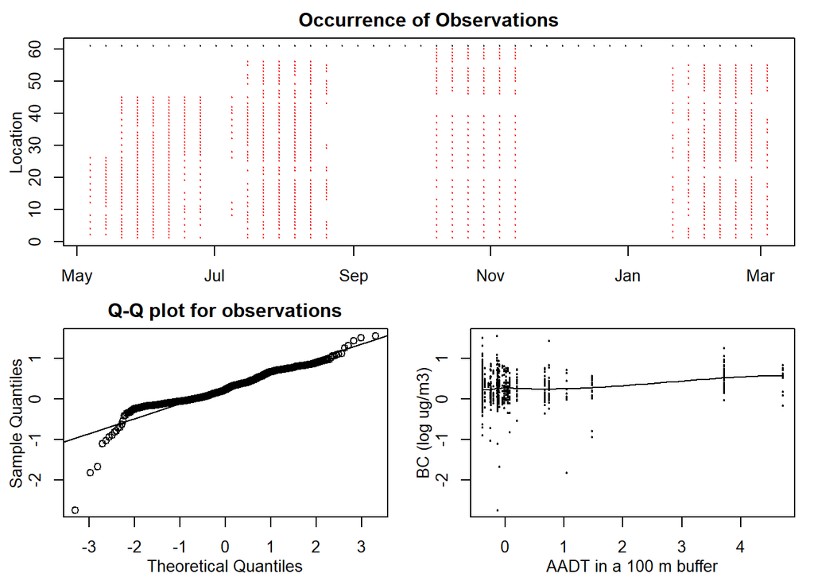

```r
layout(matrix(c(1,2,1,3), 2, 2))
par(mar=c(2.3,3.3,2,1), mgp=c(2,1,0))
plot(denver.data, "loc", main="Occurrence of Observations", xlab="",
     ylab="Location", col=c("black", "red"), legend.loc=NULL)
par(mar=c(3.3,3.3,2,1))
qqnorm(denver.data, line=1)
scatterPlot(denver.data, covar="aadt_100", xlab="AADT in a 100 m buffer",
            ylab="BC (log ug/m3)", pch=19, cex=.25,
            smooth.args=list(span=4/5,degree=2))
```

#’ Step 3: Determine the number of basis functions

```r
D <- createDataMatrix(denver.data)
D
```

```
##              central          d_1          d_10        d_11        d_12
## 2018-05-07 0.3895686           NA            NA          NA -0.22899258
## 2018-05-14 0.2713538           NA            NA -0.10308027 -0.28227976
## 2018-05-21 0.3867741 -0.365566729 -1.251495e-01  0.06346648 -0.21750800
## 2018-05-28 0.1620344 -0.074245068 -2.387712e-01 -0.01832386 -0.39677460
## 2018-06-04 0.3821048 -0.026107890 -1.638067e-01  0.02676124 -0.11283841
## 2018-06-11 0.2461541  0.121880791 -1.189136e-01  0.14237827 -0.05039006
## 2018-06-18 0.2037397 -0.021857706 -1.889458e-01  0.05794523          NA
## 2018-06-25 0.3539322  0.060479689 -1.587464e-01  0.20852302          NA
## 2018-07-02 0.1453478           NA            NA          NA          NA
## 2018-07-09 0.3436777           NA -1.550559e-01          NA -0.32399670
## 2018-07-16 0.4975615  0.076014819            NA  0.17466941 -0.06231967
## 2018-07-23 0.4686300  0.005163425 -1.618769e-01  0.02376054 -0.17543767
## 2018-07-30 0.4858728  0.218015873 -1.471006e-05  0.31603303  0.04230987
## 2018-08-06 0.5500664  0.097252339 -6.462108e-02  0.16679795 -0.04620736
## 2018-08-13 0.6747657  0.319823617  1.442808e-01  0.39319539  0.10109425
## 2018-08-20 0.9338012  0.156171166            NA          NA          NA
## 2018-08-27 0.6584053           NA            NA          NA          NA
## 2018-09-03 0.6692100           NA            NA          NA          NA
## 2018-09-10 0.5505576           NA            NA          NA          NA
## 2018-09-17 0.5813824           NA            NA          NA          NA
## 2018-09-24 0.3992762           NA            NA          NA          NA
## 2018-10-01 0.9041427           NA            NA          NA          NA
## 2018-10-08 0.3351656  0.396599926            NA  0.44635109          NA
## 2018-10-15 0.5376239  0.373807062            NA  0.46656999          NA
## 2018-10-22 0.8152706  0.491363889            NA  0.48119769          NA
## 2018-10-29 0.4553577  0.320164657            NA  0.35591100          NA
## 2018-11-05 0.5704430  0.430844008            NA  0.50549558          NA
## 2018-11-12 0.5606328  0.427957321            NA  0.51833913          NA
## 2018-11-19 0.6015120           NA            NA          NA          NA
## 2018-11-26 0.9688893           NA            NA          NA          NA
## 2018-12-03 0.7321681           NA            NA          NA          NA
## 2018-12-10 1.0497450           NA            NA          NA          NA
## 2018-12-17 0.7988333           NA            NA          NA          NA
## 2018-12-24 0.2446862           NA            NA          NA          NA
## 2018-12-31 0.8297826           NA            NA          NA          NA
## 2019-01-07 1.2396159           NA            NA          NA          NA
## 2019-01-21 0.2874374  0.472979349            NA          NA  0.75686368
## 2019-01-28 0.7089227  0.671310562 -2.321684e-01          NA  0.71686566
## 2019-02-04 0.8079997 -0.144899191  6.674364e-01  0.46794846  0.66034413
```

[output cut: 517 more lines]

```
## 2018-11-19          NA          NA
## 2018-11-26          NA          NA
## 2018-12-03          NA          NA
## 2018-12-10          NA          NA
## 2018-12-17          NA          NA
## 2018-12-24          NA          NA
## 2018-12-31          NA          NA
## 2019-01-07          NA          NA
## 2019-01-21          NA  0.64752218
## 2019-01-28  0.40013768          NA
## 2019-02-04  0.16831425 -2.73389519
## 2019-02-11  0.68577499  0.61146962
## 2019-02-18  0.75823116  0.68460585
## 2019-02-25  0.70448210  0.39592326
## 2019-03-04  0.10016481 -0.29492063
```

```r
SVD.cv <- SVDsmoothCV(D, 0:4)
SVD.cv
```

```
## Result of SVDsmoothCV, average of CV-statistics:
##                  MSE        R2       AIC       BIC
## n.basis.0 0.11170599 0.0000000 -43.60613 -42.70617
## n.basis.1 0.05807273 0.5259558 -62.29349 -60.49357
## n.basis.2 0.04031137 0.6557915 -65.10345 -62.40358
## n.basis.3 0.03299570 0.7221955 -68.86686 -65.26703
## n.basis.4 0.02766235 0.7936786 -72.02049 -67.52071
```

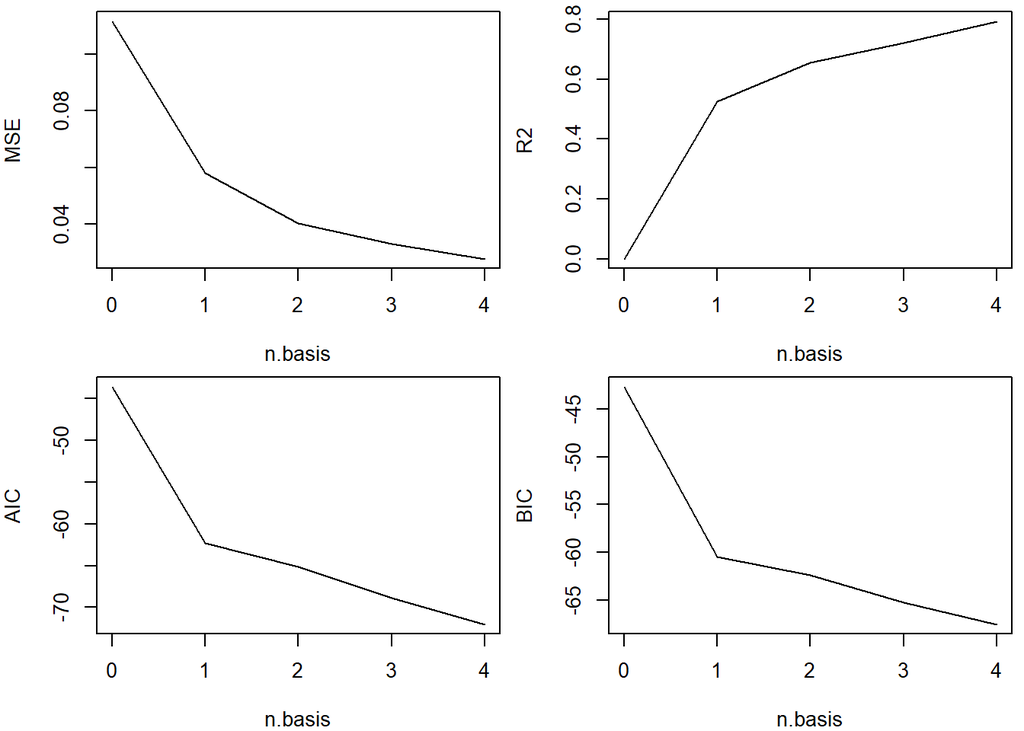

```r
plot(SVD.cv)
```

Just like in the tutorial, our curves tend to flatten out at 2 basis functions. However, based on Josh Keller’s feedback, I’m going to start with the simplest model just to make sure things are working correctly. This means using 1 temporal basis function for now.

```r
denver.data <- updateTrend(denver.data, n.basis = 1)
```

```
## Replacing existing trend.
```

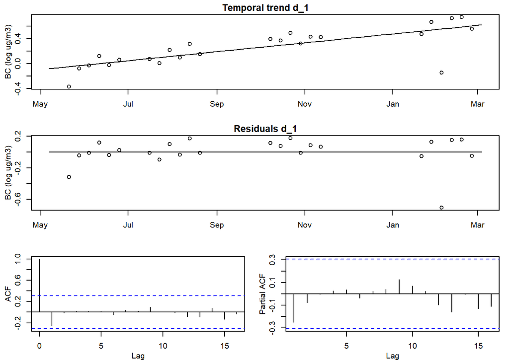

```r
#' Step 4: Evaluate the basis functions
par(mar=c(3.3,3.3,1.5,1), mgp=c(2,1,0))
layout(matrix(c(1,1,2,2,3,4), 3, 2, byrow=TRUE))
plot(denver.data, "obs", ID="d_1", xlab="", ylab="BC (log ug/m3)",
     main="Temporal trend d_1")
plot(denver.data, "res", ID="d_1", xlab="", ylab="BC (log ug/m3)")
plot(denver.data, "acf", ID="d_1")
plot(denver.data, "pacf", ID="d_1")
```

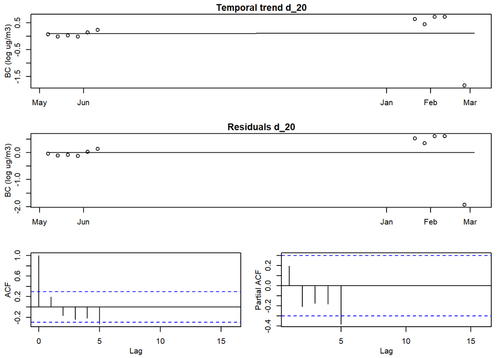

```r
par(mar=c(3.3,3.3,1.5,1), mgp=c(2,1,0))
layout(matrix(c(1,1,2,2,3,4), 3, 2, byrow=TRUE))
plot(denver.data, "obs", ID="d_20", xlab="", ylab="BC (log ug/m3)",
     main="Temporal trend d_20")
plot(denver.data, "res", ID="d_20", xlab="", ylab="BC (log ug/m3)")
plot(denver.data, "acf", ID="d_20")
plot(denver.data, "pacf", ID="d_20")
```

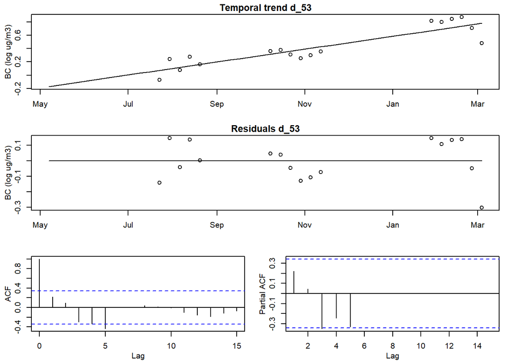

```r
par(mar=c(3.3,3.3,1.5,1), mgp=c(2,1,0))
layout(matrix(c(1,1,2,2,3,4), 3, 2, byrow=TRUE))
plot(denver.data, "obs", ID="d_53", xlab="", ylab="BC (log ug/m3)",
     main="Temporal trend d_53")
plot(denver.data, "res", ID="d_53", xlab="", ylab="BC (log ug/m3)")
plot(denver.data, "acf", ID="d_53")
plot(denver.data, "pacf", ID="d_53")
```

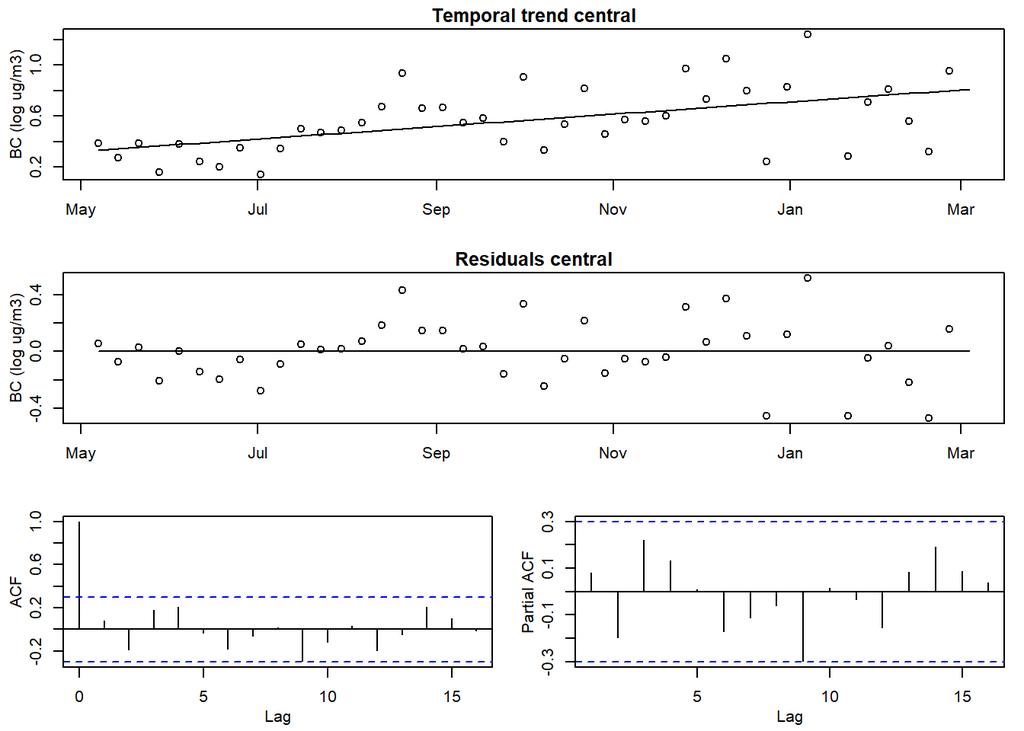

```r
par(mar=c(3.3,3.3,1.5,1), mgp=c(2,1,0))
layout(matrix(c(1,1,2,2,3,4), 3, 2, byrow=TRUE))
plot(denver.data, "obs", ID="central", xlab="", ylab="BC (log ug/m3)",
     main="Temporal trend central")
plot(denver.data, "res", ID="central", xlab="", ylab="BC (log ug/m3)")
plot(denver.data, "acf", ID="central")
plot(denver.data, "pacf", ID="central")
```

### Step 4: Fit the model

#### Step 4.1: Compute the regression coefficients

Note: When I did this with the full data set, something seemed very different about distributed site 61. The coefficients were much larger than for the other sites. For now, I will drop this site from the data set.

```r
names(denver.data$covars)
```

```
##  [1] "ID"              "lon"             "lat"
##  [4] "tree_cover_100"  "low_int_100"     "dist_m_military"
##  [7] "dist_m_rail"     "aadt_100"        "x"
## [10] "y"               "type"
```

```r
beta.lm <- estimateBetaFields(denver.data)
beta.lm
```

```
## $beta
##              const            V1
## central 0.56856397  0.1417682962
## d_1     0.26673503  0.2093935134
## d_10    0.17064599  0.2743297537
## d_11    0.20796916  0.0282118512
## d_12    0.17528398  0.2829347253
## d_13    0.15675546 -0.0725529969
## d_14    0.30897001  0.1968562633
## d_15    0.27594604  0.1165960546
## d_16    0.15204203  0.1247279903
## d_17    0.25136203  0.2748407401
## d_18    0.26088164  0.2604899199
## d_19    0.27461027  0.3119387502
## d_2     0.32213899  0.2387588989
## d_20    0.09979545  0.0031786366
## d_21    0.14879190  0.0327565129
## d_22    0.32318106  0.3010064278
## d_23    0.30222383  0.2265929836
## d_24    0.31465031  0.2416840233
## d_25    0.26875025  0.2882137066
## d_26    0.28289663  0.3180938747
## d_27    0.25168965  0.2217451626
## d_28    0.27058748  0.1903442495
## d_29    0.25273374  0.1230719104
## d_3     0.36325557  0.2360537439
## d_30    0.25481979  0.2105798958
## d_31    0.18369606  0.1998397118
## d_32    0.26957106  0.2438944479
## d_33    0.30273852  0.2013157884
## d_34    0.26400045  0.2649369122
## d_35    0.27857674  0.1967589905
## d_36    0.21366394  0.2995050161
## d_37    0.21061115  0.1567388187
## d_38    0.24237638  0.2448670735
## d_39    0.27901003  0.0564657614
## d_4     0.24072096  0.1535744256
## d_40    0.07934401 -0.0210728989
## d_41    0.43058185  0.3134887623
## d_42    0.19387840  0.0609459656
```

[output cut: 72 more lines]

```
## d_50    0.05547065 0.05584549
## d_51    0.05069927 0.04990367
## d_52    0.03489676 0.03518589
## d_53    0.03587025 0.03653035
## d_54    0.03518830 0.03605523
## d_55    0.10177878 0.08644600
## d_56    0.06766868 0.11002399
## d_57    0.03847327 0.13098816
## d_58    0.03895227 0.13261896
## d_59    0.03324913 0.11320176
## d_6     0.08055484 0.07034634
## d_60    0.05952788 0.20267178
## d_7     0.03470933 0.03098306
## d_8     0.04835265 0.03733698
## d_9     0.15163601 0.14291973
```

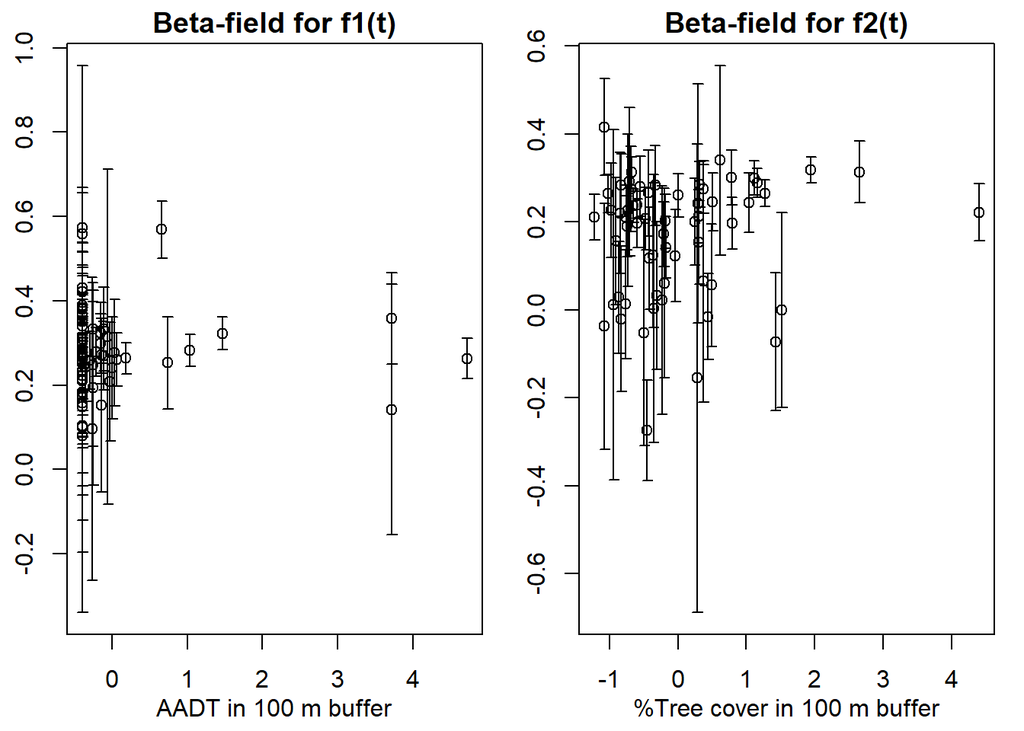

```r
par(mfrow=c(1,2), mar=c(3.3,2.3,1.5,1), mgp=c(2,1,0))
plotCI(denver.data$covars$aadt_100, beta.lm$beta[,1],
       uiw=1.96*beta.lm$beta.sd[,1], ylab="", xlab="AADT in 100 m buffer",
       main="Beta-field for f1(t)")
plotCI(denver.data$covars$tree_cover_100, beta.lm$beta[,2],
       uiw=1.96*beta.lm$beta.sd[,2], ylab="", xlab="%Tree cover in 100 m buffer",
       main="Beta-field for f2(t)")
```

#### Step 4.2: Create the model object

Here we can specify different LUR formluae. The length of the LUR list should be number of time functions + 1. For now, going to use a very simple model with the covariance structures set to iid

```r
names(denver.data$covars)
```

```
##  [1] "ID"              "lon"             "lat"
##  [4] "tree_cover_100"  "low_int_100"     "dist_m_military"
##  [7] "dist_m_rail"     "aadt_100"        "x"
## [10] "y"               "type"
```

```r
LUR <- list(~low_int_100 + dist_m_military + dist_m_rail + aadt_100,
            ~aadt_100)
cov.beta <-  list(covf="iid", nugget = T)
cov.nu <- list(covf="iid", nugget = ~type, random.effect = FALSE)
locations <- list(coords = c("x","y"), long.lat = c("lon","lat"), others= "type")

denver.model <- createSTmodel(denver.data, LUR = LUR,
                              ST = c("bc_st_no2"),
                              cov.beta = cov.beta, cov.nu = cov.nu,
                              locations = locations)
denver.model
```

```
## STmodel-object with:
##  No. locations: 61 (observed: 61)
##  No. time points: 43 (observed: 43)
##  No. obs: 1038
##
## Trend with 1 basis function(s):
## [1] "V1"
## with dates:
##  2018-05-07 to 2019-03-04
##
## Models for the beta-fields are:
## $const
## ~low_int_100 + dist_m_military + dist_m_rail + aadt_100
##
## $V1
## ~aadt_100
##
## 1 spatio-temporal covariate(s):
## [1] "bc_st_no2"
##
## Covariance model for the beta-field(s):
##  Covariance type(s): iid, iid
##  Nugget: Yes, Yes
## Covariance model for the nu-field(s):
##  Covariance type: iid
##  Nugget: ~type
##  Random effect: No
## All sites:
## central    dist
##       1      60
## Observed:
## central    dist
##       1      60
##
## For central:
##   Number of obs: 42
##   Dates: 2018-05-07 to 2019-02-25
## For dist:
##   Number of obs: 996
##   Dates: 2018-05-07 to 2019-03-04
```

#### Step 4.2: Estimate model parameters

From the tutorial: To avoid potential numerical optimisation issues, the estimation function allows for multiple starting points, returning all optima found. The functions loglikeSTdim and loglikeSTnames gives the number of parameters (and other model dimension) and the names, i.e. expected order, of the parameters. Using this information a two column matrix, where each column represents a different optimisation starting point, is constructed:

Note: need to ask Josh what the best way to go about choosing these intial values is!

```r
dim <- loglikeSTdim(denver.model)
dim
```

```
## $T
## [1] 43
##
## $m
## [1] 2
##
## $n
## [1] 61
##
## $n.obs
## [1] 61
##
## $p
## const    V1
##     5     2
##
## $L
## [1] 1
##
## $npars.beta.covf
## iid iid
##   0   0
##
## $npars.beta.tot
## iid iid
##   1   1
##
## $npars.nu.covf
## [1] 0
##
## $npars.nu.tot
## [1] 2
##
## $nparam.cov
## [1] 4
##
## $nparam
## [1] 12
```

```r
x.init <- cbind(c( rep(2, dim$nparam.cov-1), 0),
                c( rep(c(3,-1), dim$m)))

rownames(x.init) <- loglikeSTnames(denver.model, all=FALSE)
x.init
```

```
##                               [,1] [,2]
## log.nugget.const.iid             2    3
## log.nugget.V1.iid                2   -1
## nu.log.nugget.(Intercept).iid    2    3
## nu.log.nugget.typedist.iid       0   -1
```

```r
#' Difference from tutorial: use Josh Keller's version of the function
est.denver.model <- estimate.STmodel(denver.model, x.init)
```

```
## Optimisation using starting value 1/2
```

[output not shown]

```
## Optimisation using starting value 2/2
```

```
## N = 4, M = 5 machine precision = 2.22045e-16
## At X0, 0 variables are exactly at the bounds
## At iterate     0  f=         1197  |proj g|=           18
## At iterate    10  f =      -830.88  |proj g|=        13.714
## At iterate    20  f =      -860.03  |proj g|=       0.48551
## Bad direction in the line search;
##    refresh the lbfgs memory and restart the iteration.
##
## iterations 23
## function evaluations 66
## segments explored during Cauchy searches 27
## BFGS updates skipped 0
## active bounds at final generalized Cauchy point 0
## norm of the final projected gradient 0.057973
## final function value -860.048
##
## F = -860.048
```

```r
print(est.denver.model)
```

```
## Optimisation for STmodel with 2 starting points.
##   Results: 2 converged, 0 not converged, 0 failed.
##   Best result for starting point 1, optimisation has converged
##
## No fixed parameters.
##
## Estimated parameters for all starting point(s):
##                                       [,1]         [,2]
## gamma.bc_st_no2               -0.006993167 -0.006996552
## alpha.const.(Intercept)        0.412721213  0.412792560
## alpha.const.low_int_100       -0.017208630 -0.017208119
## alpha.const.dist_m_military    0.001605268  0.001606246
## alpha.const.dist_m_rail        0.005550627  0.005550653
## alpha.const.aadt_100           0.060121362  0.060113261
## alpha.V1.(Intercept)           0.215015218  0.215027780
## alpha.V1.aadt_100             -0.062142740 -0.062142983
## log.nugget.const.iid          -6.325855694 -6.323413179
## log.nugget.V1.iid             -5.052236357 -5.053499426
## nu.log.nugget.(Intercept).iid -2.845827796 -2.844472149
## nu.log.nugget.typedist.iid     0.108376847  0.107001397
##
## Function value(s):
## [1] 860.0478 860.0477
```

```r
data(est.mesa.model, package="SpatioTemporal")
print(est.mesa.model)
```

```
## Optimisation for STmodel with 2 starting points.
##   Results: 2 converged, 0 not converged, 0 failed.
##   Best result for starting point 1, optimisation has converged
##
## No fixed parameters.
##
## Estimated parameters for all starting point(s):
##                                          [,1]          [,2]
## gamma.lax.conc.1500              0.0008975546  0.0009008652
## alpha.const.(Intercept)          3.7402698246  3.7406058853
## alpha.const.log10.m.to.a1       -0.2021288763 -0.2022633497
## alpha.const.s2000.pop.div.10000  0.0402182221  0.0401923686
## alpha.const.km.to.coast          0.0374363255  0.0374629689
## alpha.V1.(Intercept)            -0.7429226257 -0.7411611359
## alpha.V1.km.to.coast             0.0174017754  0.0172645957
## alpha.V2.(Intercept)            -0.1292573245 -0.1281826343
## alpha.V2.km.to.coast             0.0155467684  0.0154883000
## log.range.const.exp              2.4245453422  2.4205527321
## log.sill.const.exp              -2.7522202309 -2.7568455241
## log.range.V1.exp                 2.9175969067  2.9484089871
## log.sill.V1.exp                 -3.5231738064 -3.5086290882
## log.range.V2.exp                 1.7816565861  1.8062154010
## log.sill.V2.exp                 -4.6812486307 -4.6730245593
## nu.log.range.exp                 4.3836003026  4.3839197279
## nu.log.sill.exp                 -3.2126038230 -3.2123312163
## nu.log.nugget.(Intercept).exp   -4.4121007058 -4.4118479775
## nu.log.nugget.typeFIXED.exp      0.6766505805  0.6748262774
##
## Function value(s):
## [1] 5748.563 5748.561
```

### Step 5: Predictions

In order to get this to work, I’m going to use with `only.obs = T` option. When I tried to use the predict function without setting `only.obs = T`, I got NA values in each of the columns for the pred$LAT object.

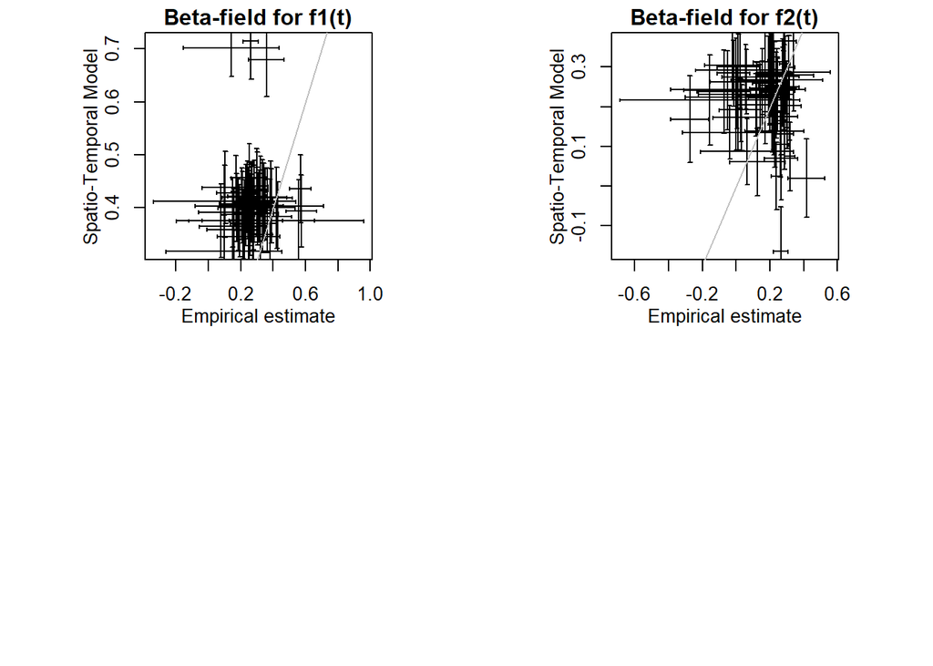

```r
pred <- predict(denver.model, est.denver.model, denver.data,
                only.obs = T, LTA = T, type = "p")
pred.log <- predict(denver.model, est.denver.model, denver.data,
                    only.obs = T, LTA = T,
                    transform = "unbiased", type = "p")

par(mfrow=c(2,2), mar=c(3.3,3.3,1.5,1), mgp=c(2,1,0), pty="s")
for(i in 1:ncol(beta.lm$beta)){
  plotCI(x=beta.lm$beta[,i], y=pred$beta$EX[,i],
         uiw=1.96*beta.lm$beta.sd[,i], err="x",
         pch=NA, sfrac=0.005,
         main=paste("Beta-field for f", i, "(t)", sep=""),
         xlab="Empirical estimate",
         ylab="Spatio-Temporal Model")
  plotCI(x=beta.lm$beta[,i], y=pred$beta$EX[,i],
         uiw=1.96*sqrt(pred$beta$VX[,i]),
         add=TRUE, pch=NA, sfrac=0.005)
  abline(0, 1, col="grey")
}

par(mfrow=c(1,2), mar=c(3.3,3.3,1.5,1), mgp=c(2,1,0))
```

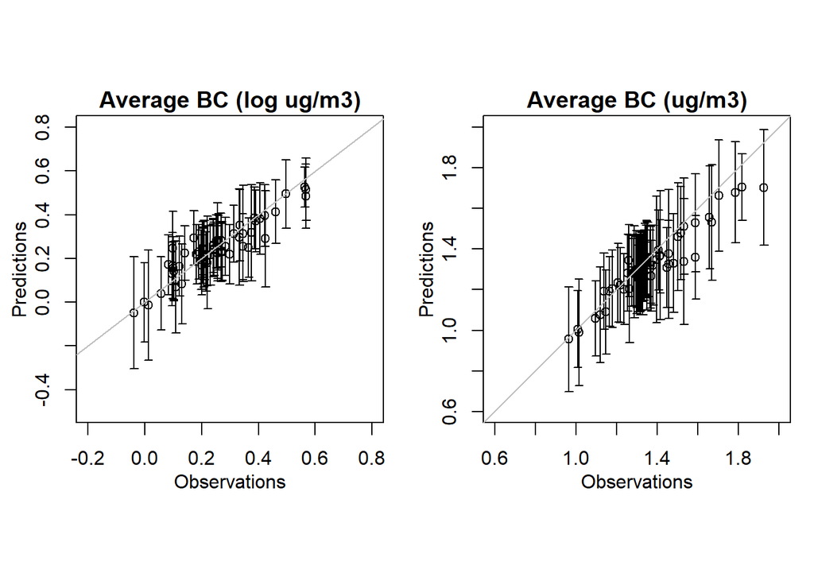

```r
with(pred$LTA, plotCI(colMeans(D, na.rm=TRUE), EX, uiw=1.96*sqrt(VX.pred),
                      xlim=c(-0.2,0.8), ylim=c(-0.5,0.8),
                      ylab="Predictions", xlab="Observations",
                      main="Average BC (log ug/m3)"))
abline(0, 1, col="grey")
with(pred.log$LTA, plotCI(colMeans(exp(D), na.rm=TRUE),
                          EX, uiw=1.96*sqrt(VX.pred),
                          xlim=c(0.6,2), ylim=c(0.6,2),
                          ylab="Predictions", xlab="Observations",
                          main="Average BC (ug/m3)"))
abline(0, 1, col="grey")
```

### Step 6: Cross-validation and model evaluation

NOT RUN YET– NEED TO HAVE THE ABOVE RESULTS REVIEWED BEFORE MOVING FORWARD I tried to run the code below, but had an error when using the `estimate.cv` function. Maybe related to the issue Josh wrote about re: the estimate function?

#### Step 6.1: Define CV groups

```r
# Ind.cv <- createCV(denver.model, groups = 10, min.dist = .1)
```

The number of locations is roughly even, though the number of observations differs by group– remember! This is an unbalanced design

```r
# ID.cv <- sapply(split(denver.model$obs$ID, Ind.cv), unique)
# print( sapply(ID.cv, length) )
# table(Ind.cv)
```

#### Step 6.2: ID starting conditions using previous model without CV

```r
# x.init <- coef(est.denver.model, pars="cov")[,c("par","init")]
# x.init
```

#### Step 6.3 : Run the model– computationally intensive!!

I attempted to run this model using the previous model without CV from above. I got an error when trying to run the first time:

Estimation of CV-set 10/10 Error in stCheckX(x, x.fixed, dimensions, type, object) : dim(x)[1] must be 11 or 3 In addition: Warning message: In value[3L] : Some covariates are constant or factors with only one level in the specification of the nugget. This will result in unidentifiable parameters. To avoid this the following elemets of the formula have been dropped: typedist

```r
# est.cv.denver <- estimateCV(denver.model, x.init, Ind.cv)
# print(est.cv.denver)
#
# par(mfrow=c(1,1), mar=c(13.5,2.5,.5,.5), las=2)
# with(coef(est.denver.model, pars="all"),
#      plotCI((1:length(par))+.3, par, uiw=1.96*sd,
#             col=2, xlab="", xaxt="n", ylab=""))
# boxplot(est.cv.denver, "all", boxwex=.4, col="grey", add=TRUE)
```

#’ Step 7: Prediction using the CV model Again, this is computationally intensive

```r
# pred.cv.denver <- predictCV(denver.model, est.cv.denver, LTA=TRUE)
#
# summary(pred.cvdenver.log)
# summary(pred.cv.denver.log, by.date=TRUE)
#
# par(mar=c(3.3,3.3,1.5,1), mgp=c(2,1,0))
# layout(matrix(c(1,1,2,2,3,4,5,6), 4, 2, byrow=TRUE))
# plot(pred.cv.mesa, ID="60371601", xlab="", ylab="NOx (log ppb)",
#      main="Predictions for 60371601", lty=c(1,NA), lwd=2,
#      pch=c(NA,19), cex=.75)
# plot(pred.cv.mesa, ID="60371601", pred.type="EX.mu",
#      lty=4, lwd=2, col="blue", add=TRUE)
# plot(pred.cv.mesa, ID="60371601", pred.type="EX.mu.beta",
#      lty=2, lwd=2, col="green", add=TRUE)
# plot(pred.cv.mesa.log, ID="60371601", xlab="", ylab="NOx (ppb)",
#      main="Predictions for 60371601", pred.type="EX.pred",
#      lty=c(1,NA), lwd=2, pch=c(NA,19), cex=.75)
# plot(pred.cv.mesa.log, ID="60371601", pred.type="EX.mu",
#      lty=4, lwd=2, col="blue", add=TRUE)
# plot(pred.cv.mesa.log, ID="60371601", pred.type="EX.mu.beta",
#      lty=2, lwd=2, col="green", add=TRUE)
# legend("topright", c("Observations", "Predictions",
#                      "Contribution from beta",
#                      "Contribution from mean",
#                      "95% CI"), bty="n",
#        lty=c(NA,1,2,4,NA), lwd=c(NA,2,2,2,NA),
#        pch=c(19,NA,NA,NA,15), pt.cex=c(.75,NA,NA,NA,2.5),
#        col=c("red", "black", "green", "blue", "grey"))
# plot(pred.cv.mesa, "obs", ID="all", pch=c(19,NA), cex=.25, lty=c(NA,2),
#      col=c("ID", "black", "grey"), xlab="Observations",
#      ylab="Predictions", main="Cross-validation NOx (log ppb)")
# with(pred.cv.mesa.log$pred.LTA, plotCI(obs, EX.pred, uiw=1.96*sqrt(VX.pred),
#                                        xlab="Observations", ylab="Predictions",
#                                        main="Temporal average NOx (ppb)"))
# abline(0, 1, col="grey")
# I.season <- as.factor(as.POSIXlt(pred.cv.mesa$pred.obs$date)$mon+1)
# levels(I.season) <- c(rep("Winter",2), rep("Spring",3),
#                       rep("Summer",3), rep("Fall",3), "Winter")
# qqnorm(pred.cv.mesa, norm=TRUE, main="Normalised residuals",
#        col=I.season)
# legend("bottomright", legend=as.character(levels(I.season)),
#        pch=1, col=1:nlevels(I.season), bty="n")
# scatterPlot(pred.cv.mesa, STdata=mesa.model, covar="log10.m.to.a1",
#             group=I.season, col=c(2:5,1), type="res",
#             xlab="Distance to A1-Road", ylab="Residuals",
#             main="Residuals (log ppb)")
```

#### Josh Keller’s advice for fitting the model

Pasting here for safe keeping

Your sleuthing about that error is correct. A singular hessian matrix (the hessian is a like a matrix analogue of a second derivative) is symptomatic of the optimization algorithm not finding the true minimum. I remember this error all too well! To deal with this, I suggest the following:

- Use the version of estimate.STmodel() in the attached file instead of the one that is in the package. If you load the package, then source this file, it will overwrite the package function so you can use this version. This version has two changes:
  - It changes the error handling to catch the non-invertible warning and output an obviously wrong value for the standard deviation (-1000). This doesn’t fix the problem at all, but keeps the function from aborting, as the package version does, since the abort makes you lose all of your results that far. This makes it more practical to use multiple starting values in a single function call, since it won’t abort half way through.
  - It uses the function hessian() from the `numDeriv` package to provide a more numerically-accurate estimate of the Hessian matrix. The package version of the hessian is still stored in the `optim_hessian` object, while the new version is in the `hessian` object. This means you’ll need to install the numDeriv package.
- Try a set of different initial conditions. The numerical algorithm used to maximize the likelihood can get stuck in some areas, so using a set of several initial conditions is a good way to try to ensure that you’re getting the best solution. The package should be able to loop through several initial values and pick the one giving the best result. Let me know if you’d like any suggested values to try.
- Try a simpler model. I’m not sure exactly what model structure you’re using, but it often helps to start with a smaller model (e.g. 1 time trend, and iid covariance structure) to get a sense of the ranges of the parameters. You can then use the estimates from the simpler model as approximate starting values for a more complicated fit.